# PIRUS

```r
# Load libraries
library(readr)
library(tidyverse)
library(scales)
library(data.table)
# Load code
PIRUSV5 <- read_csv("PIRUSV5.csv")
View(PIRUSV5)
```

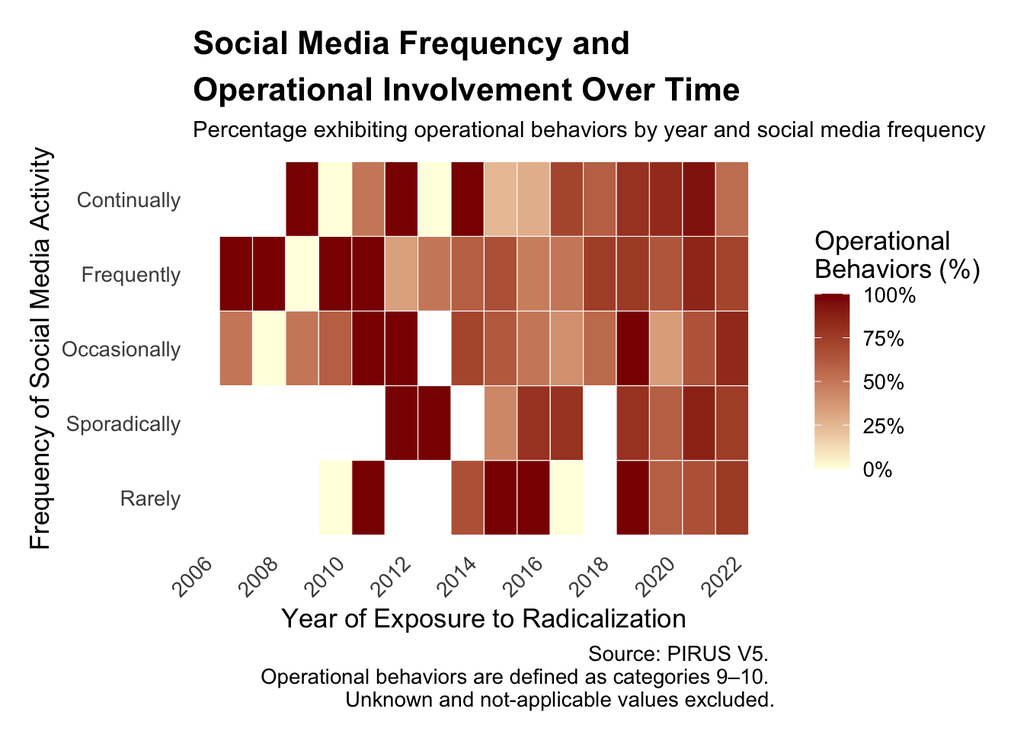

```r
# Prepare the data
heatmap_data <- PIRUSV5 %>%
  filter(
    Social_Media_Frequency %in% 1:5,
    Radical_Behaviors %in% 0:10,
    !is.na(Year_Exposure)
  ) %>%
  mutate(
    Social_Media_Frequency = factor(
      Social_Media_Frequency,
      levels = 1:5,
      labels = c(
        "Rarely",
        "Sporadically",
        "Occasionally",
        "Frequently",
        "Continually"
      )
    ),
    Operational_Behavior = Radical_Behaviors %in% 9:10
  )

# Calculate the percentage exhibiting operational behaviors
heatmap_summary <- heatmap_data %>%
  group_by(Year_Exposure, Social_Media_Frequency) %>%
  summarise(
    Total = n(),
    Operational = sum(Operational_Behavior),
    Percentage = Operational / Total * 100,
    .groups = "drop"
  )

# Create the heatmap
ggplot(
  heatmap_summary,
  aes(
    x = Year_Exposure,
    y = Social_Media_Frequency,
    fill = Percentage
  )
) +
  geom_tile(color = "white", linewidth = 0.2) +
  scale_fill_gradient(
    low = "lightyellow",
    high = "darkred",
    labels = function(x) paste0(round(x), "%"),
    name = "Operational\nBehaviors (%)"
  ) +
  scale_x_continuous(
    breaks = pretty_breaks(n = 10)
  ) +
  labs(
  title = "Social Media Frequency and\nOperational Involvement Over Time",
  subtitle = "Percentage exhibiting operational behaviors by year and social media frequency",
  x = "Year of Exposure to Radicalization",
  y = "Frequency of Social Media Activity",
  caption = paste(
  "Source: PIRUS V5.",
  "\nOperational behaviors are defined as categories 9–10.",
  "\nUnknown and not-applicable values excluded."
)
) +
theme_minimal(base_size = 13) +
theme(
  plot.title = element_text(
    face = "bold",
    size = 16,
    lineheight = 1.2
  ),
  plot.subtitle = element_text(size = 11),
  plot.margin = margin(t = 15, r = 15, b = 10, l = 15),
  panel.grid = element_blank(),
  axis.text.x = element_text(angle = 45, hjust = 1)
)
```

## NARRATIVE

This visualization explores the relationship between social media activity and operational involvement among individuals included in the PIRUS V5 dataset. Specifically, it asks: How does the frequency of social media activity relate to the percentage of individuals exhibiting operational behaviors, and how does this relationship change over time? This question is important for understanding how online activity may intersect with different levels of involvement in radicalization.

The heatmap displays the percentage of individuals exhibiting operational behaviors (categories 9–10) across years of exposure to radicalization and five levels of social media activity: rarely, sporadically, occasionally, frequently, and continually. Each cell represents a year and activity-frequency combination. The color scale ranges from pale yellow, indicating a lower percentage, to dark red, indicating a higher percentage. Blank cells represent combinations for which no data are displayed. Unknown and not-applicable values are excluded from the analysis.

The visualization shows substantial variation in operational behavior percentages across both time and social media frequency. Some year-frequency combinations show high percentages, while others show lower percentages, and the pattern does not follow a consistent upward or downward trend. However, these percentages should be interpreted cautiously because the number of individuals represented in each cell may vary. The heatmap shows an association between social media frequency and operational involvement within this dataset, but it does not establish that more frequent social media activity causes greater operational involvement.